# A/B Testing with Permutations (in R)

August 27, 2020

## Outline

**A/B Testing**

- What? & Why?
- Examples
- How? (Steps)

**Permutation Test**

- What? & Why?
- How? (Steps)
- Hypothesis Testing

**Code**

*R Shiny App*

## A/B Test – What? & Why?

## A/B Test – What? & Why?

**What?** An experiment to compare two competing *options* (A, B).

- *Options:* treatments (medical), designs (ad, web), products, prices, etc.

**Why?** To determine if the options are *different*.

- *Different* in a statistical sense (hypothesis testing, permutation test).

**Why?** To determine what’s the *better* option.

- *Better* for the question/goal at hand (customer acquisition, profit, etc).

## A/B Test – Examples?

## A/B Test – Examples? – General

**Two soil treatments:** which one promotes *better seed germination*?

**Two web headlines:** which one produces *more clicks*?

**Two web ads:** which one generates *more conversions*?

**Two prices:**

- which one yields a *higher net profit*?
- which one leads to *more new costumers*?

**Two therapies:** which one is *more effective at suppressing cancer*?

- **Control group:** subjects exposed to *no treatment* or *standard treatment*.
- **Treatment group:** subjects exposed to the *new treatment*.

## A/B Test – Examples? – Specific

**Microsoft (Bing):**

- one A/B test
- changing the way the Bing search engine displayed ad headlines
- led to a 12% increase in revenue
- that’s more than $100 million per year in the US alone

**Amazon:**

- moving credit card offers from its home page to the shopping cart page
- boosted profits by tens of millions of dollars annually

**Google & Bing:** only 10% to 20% of experiments generate positive results

Reference: [The Surprising Power of Online Experiments (Harvard Business Review, 2017)](https://hbr.org/2017/09/the-surprising-power-of-online-experiments)

## A/B Test – How?

## A/B Test – How? – Didactic Example

A/B test results (e.g., in a web context):

|  | Option A | Option B |
| --- | --- | --- |
| Total | 10 | 10 |
| No | 3 | 6 |
| Yes | 7 | 4 |
| Yes Rate (%) | 70 % | 40 % |

**Test statistic:** Yes Rate Difference (A - B) (%) = 70% - 40% = 30 %

**Question:** Is this difference (statistically) significant?

(Note: this example uses small/unrealistic numbers for didactic purposes.)

## A/B Test – How? – Steps

( **0. Idea & Definition:** question, goal, data/subjects, options, test statistic. )

**1. Subjects:** Set of all subjects.

**2. Randomization:** Randomly assign subjects to the two groups (A, B).

**3. Results:** Expose subjects to the different options (A, B), measure results, and compute **test statistic**.

**4. Hypothesis testing:** determine if the observed results are statistically significant. This can be done with a **permutation test**.

( **5. Action/Decision:** based on test results. )

## A/B Test – How? – Steps 1 to 3 (diagram)

[interactive chart not shown]

## A/B Test – How? – Steps 1 to 3 (diagram, subjects)

[interactive chart not shown]

## A/B Test – How? – Hypothesis Testing (Step 4)

(**Step 3:** We observed a 30% difference between A and B. **Step 4:** Is it significant?)

Thanks to **randomization** (step 2), any observed difference between A and B must be due to either:

- Random chance (e.g., in assignment of subjects), or
- A true difference between A and B

**Hypothesis testing:** Is random chance a reasonable explanation for the observed effect?

|  | **Two-way** hypothesis test | **One-way** hypothesis test |
| --- | --- | --- |
| **Null hypothesis** | \(A = B\) (A and B are the same) | \(A \leq B\) (A is worst or the same as B) |
| **Alternative hypothesis** | \(A \neq B\) (A and B are different) | \(A > B\) (A is better than B) |

**Hypothesis test:**

- Assumes that the Null hypothesis is true
- Creates the corresponding “null model” (a probability model)
- Tests whether the observed effect is a reasonable outcome of that model
  - Is the observed effect within the random variability of the “null model”?

## A/B Test – How? – Hypothesis Testing (p-value)

**P-value:** given a chance model that embodies the null hypothesis, the p-value is the probability of obtaining results as unusual/extreme as the observed result.

**Significance Level (alpha):** the probability threshold of “unusualness” (typically 0.05 or 5%). Must be defined before the experiment.

- Probability of type I error (false positive).

**Decision:**

- `p-value > alpha`: retain the null hypothesis – observed effect due to chance
- `p-value < alpha`: reject the null hypothesis – observed effect is real/significant

**Type I error (false positive)**: Mistakenly concluding that an effect is real (when it is due to chance).

**Type II error (false negative)**: Mistakenly concluding that an effect is due to chance (when it is real)

## Permutation Test

## Permutation Test – What? & Why?

**What? & Why?** Permutation test is a resampling procedure used for hypothesis testing.

**Resampling:** repeatedly sample values from the observed data to assess a statistic’s random variability.

Two main types of resampling procedures:

- *Boostrap:* resampling **with** replacement, used to assess reliability of an estimate.
- *Permutation:* resampling **without** replacement, used for hypothesis testing.

**Permutation Test:**

- A resampling procedure used for hypothesis testing
- Process for combining two (or more) data samples together, and randomly (or exhaustively) reallocating the observations to resamples
- A way to create the “null model”, and compute the p-value

## Permutation Test – How? – Steps

**Step 0:** A/B test results

**Step 1:** Combine all A/B test results (A & B) in a single dataset (a “bag”).

**Steps 2 to 5: Do one permutation:**

- **Step 2:** Shuffle the “bag”.
- **Step 3:** Randomly draw (without replacement) a resample of the size of group A.
- **Step 4:** Randomly draw (without replacement) a resample of the same size as group B (the remainder).
- **Step 5:** Record the test statistic for the A and B resamples.

**Step 6: Done many permutations:**

- Repeat the previous steps (2 to 5) a sufficient large number of times to yield a permutation distribution of the test statistic. Each time is a different permutation.

**Hypothesis testing:** Use permutation results to compute the p-value as the ratio of values that are as or more extreme than the observed test statistic (in the A/B test result).

## Permutation Test – Steps (diagram)

[interactive chart not shown]

## Permutation Test – Steps (diagram, subjects)

[interactive chart not shown]

## Permutation Test – Hypothesis Testing

Summary (counts) table of results from 100 permutations:

| Permutation Result | -50 | -30 | -10 | 10 | 30 | 50 |
| --- | --- | --- | --- | --- | --- | --- |
| Counts | 4 | 12 | 30 | 33 | 16 | 5 |

**Two-way hypothesis test** (Null: \(A = B\), Alternative: \(A \neq B\))

- Number of extreme values: 37 (= 4 + 12 + 16 + 5)
- Ratio of extreme values (p-value): **0.37** (= 37 / 100)

**One-way hypothesis test** (Null: \(A \leq B\), Alternative: \(A > B\))

- Number of positive extreme values: 21 (= 16 + 5)
- Ratio of positive extreme values (p-value): **0.21** (= 21 / 100)

## Permutation Test – Bar Plots

| Permutation Result | -50 | -30 | -10 | 10 | 30 | 50 |
| --- | --- | --- | --- | --- | --- | --- |
| Counts | 4 | 12 | 30 | 33 | 16 | 5 |

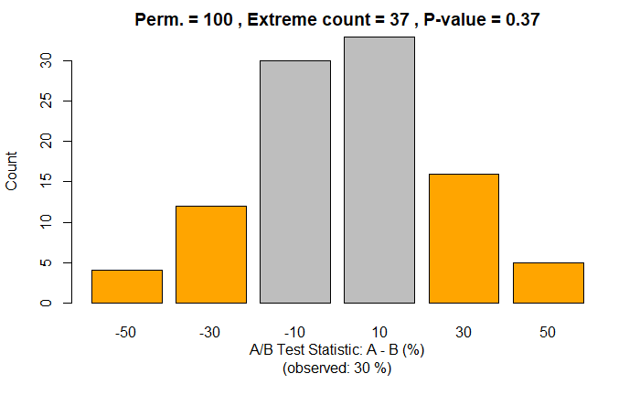

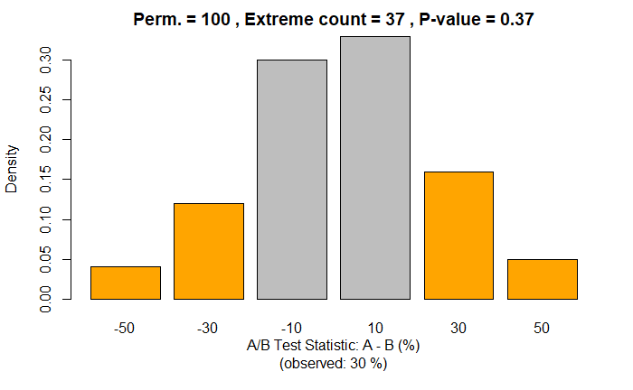

## Permutation Test – Histogram Plots

| Permutation Result | -50 | -30 | -10 | 10 | 30 | 50 |
| --- | --- | --- | --- | --- | --- | --- |
| Counts | 4 | 12 | 30 | 33 | 16 | 5 |

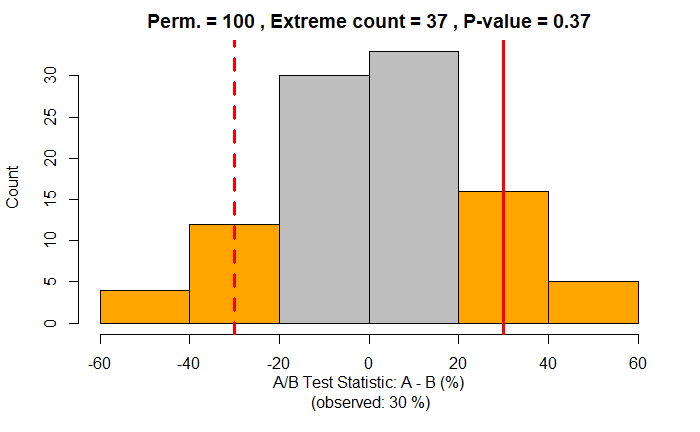

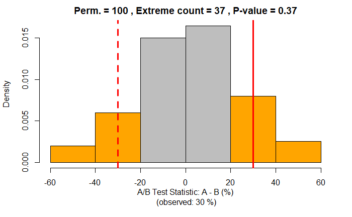

## Permutation Test – Density Plot (Probability)

| Permutation Result | -50 | -30 | -10 | 10 | 30 | 50 |
| --- | --- | --- | --- | --- | --- | --- |
| Counts | 4 | 12 | 30 | 33 | 16 | 5 |

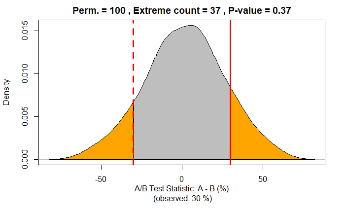

## Code

## Code – A/B Test – Didactic Example

```r
# Define minimum set of variables that fully define the A/B test results
t = 20     # Total number of subjects (A + B)
a = 10     # Number of subjects in group A
b = 10     # Number of subjects in group B
a_yes = 7  # Number of successes (yes) in group A
b_yes = 4  # Number of successes (yes) in group B

# Compute remaining A/B test results (using the variables above)
a_no = a - a_yes                # Number of failures (no) in group A
b_no = b - b_yes                # Number of failures (no) in group B
t_yes = a_yes + b_yes           # Total (A + B) successes (yes)
t_no  = a_no  + b_no            # Total (A + B) failures (no)
a_yes_pc = 100 * a_yes / a      # Percentage of successes (yes) in group A
b_yes_pc = 100 * b_yes / b      # Percentage of successes (yes) in group B
ab_yes_pc = a_yes_pc - b_yes_pc # A/B Test Statistic: Percentage of successes (yes) difference (A - B)

cat('Observed Yes Rate (%):  A:', a_yes_pc, ',  B:', b_yes_pc, ',  A-B:', ab_yes_pc)
```

```
## Observed Yes Rate (%):  A: 70 ,  B: 40 ,  A-B: 30
```

## Code – Permutation Test – One Permutation

```r
set.seed(0) # for reproducible results
bag1 = c(rep(1, t_yes), rep(0, t_no)) # Step 1: Combine all results in a bag
bag2 = sample(bag1)                   # Step 2: Shuffle the bag
a_rs = bag2[1:a]                      # Step 3: Random sample of size A
b_rs = bag2[(a+1):(a+b)]              # Step 4: Random sample of size B

# Step 5: Compute the test statistic (difference in proportion of 1s)
a_yes_pc_rs = 100 * sum(a_rs) / a
b_yes_pc_rs = 100 * sum(b_rs) / b
ab_yes_pc_rs = a_yes_pc_rs - b_yes_pc_rs

cat('(1) Bag         :', bag1,
    '\n(2) Bag shuffled:', bag2,
    '\n(3) A resample  :', a_rs,
    '\n(4) B resample  :', rep(' ', a), b_rs,
    '\n(5) Resample Yes Rate (%):  A:', a_yes_pc_rs, ',  B:', b_yes_pc_rs, ',  A-B:', ab_yes_pc_rs,
    '\n    Observed Yes Rate (%):  A:', a_yes_pc, ',  B:', b_yes_pc, ',  A-B:', ab_yes_pc)
```

```
## (1) Bag         : 1 1 1 1 1 1 1 1 1 1 1 0 0 0 0 0 0 0 0 0
## (2) Bag shuffled: 0 1 1 1 1 0 0 1 0 0 1 0 1 1 0 1 1 1 0 0
## (3) A resample  : 0 1 1 1 1 0 0 1 0 0
## (4) B resample  :                     1 0 1 1 0 1 1 1 0 0
## (5) Resample Yes Rate (%):  A: 50 ,  B: 60 ,  A-B: -10
##     Observed Yes Rate (%):  A: 70 ,  B: 40 ,  A-B: 30
```

## Code – Permutation Test – Many Permutations

```r
set.seed(1) # for reproducible results

bag = c(rep(1, t_yes), rep(0, t_no)) # Step 1: Combine all results in a bag

# Step 6: Repeat steps 2 to 5 a "large" number of times (p)
p = 100              # number of permutations
perm_res = rep(0, p) # vector for permutation results
for (i in 1:p) {
  bag = sample(bag)                               # Step 2: Shuffle the bag
  a_rs = bag[1:a]                                 # Step 3: Random sample of size A
  b_rs = bag[(a+1):(a+b)]                         # Step 4: Random sample of size B
  perm_res[i] = 100*sum(a_rs)/a - 100*sum(b_rs)/b # Step 5: Compute the test statistic
}

perm_res
```

```
##   [1]  10 -10  10 -30 -10 -30  10 -10  10 -30  10  30 -10  10 -10  10 -30  10
##  [19] -30  10  30 -10 -10 -50 -30 -10  10  10 -10 -10  10  10 -10  10 -10 -50
##  [37] -30  30 -30  10 -10 -10  30 -50 -10 -10  30  30  10  30 -50 -10  10  10
##  [55]  10 -10  10 -10  50 -30  10 -10  10  50  30 -10  10  30 -10 -10 -10  50
##  [73]  50  30  30  10  50 -30 -10 -10  30  10 -10  30  10 -10  10  30  10 -30
##  [91]  10  10  10 -10  10 -30  30  30  10 -10
```

## Code – Permutation Test – Hypothesis Testing

```r
table(perm_res)
```

```
## perm_res
## -50 -30 -10  10  30  50
##   4  12  30  33  16   5
```

```r
# Two-way hypothesis test (Null: A = B, Alternative: A != B)
extreme_count = sum(abs(perm_res) >= abs(ab_yes_pc))
extreme_ratio = extreme_count / p
# One-way hypothesis test (Null: A =< B, Alternative: A > B)
pos_extreme_count = sum(perm_res >= ab_yes_pc)
pos_extreme_ratio = pos_extreme_count / p
cat("Number of permutations                            :", p,
    "\nNumber of extreme values                          :", extreme_count,
    "\nRatio of extreme values (two-way p-value)         :", extreme_ratio,
    "\nNumber of positive extreme values                 :", pos_extreme_count,
    "\nRatio of positive extreme values (one-way p-value):", pos_extreme_ratio)
```

```
## Number of permutations                            : 100
## Number of extreme values                          : 37
## Ratio of extreme values (two-way p-value)         : 0.37
## Number of positive extreme values                 : 21
## Ratio of positive extreme values (one-way p-value): 0.21
```

## Code – Permutation Test – Bar Plot (Counts)

```
## perm_res
## -50 -30 -10  10  30  50
##   4  12  30  33  16   5
```

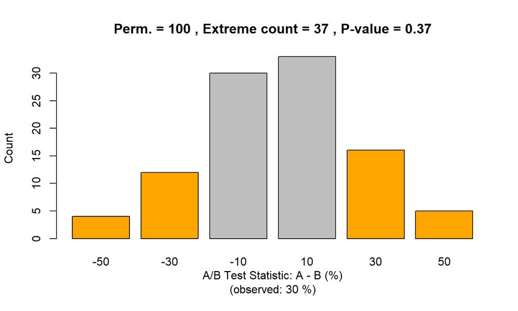

## Code – Permutation Test – Bar Plot (Probability)

```
## perm_res
## -50 -30 -10  10  30  50
##   4  12  30  33  16   5
```

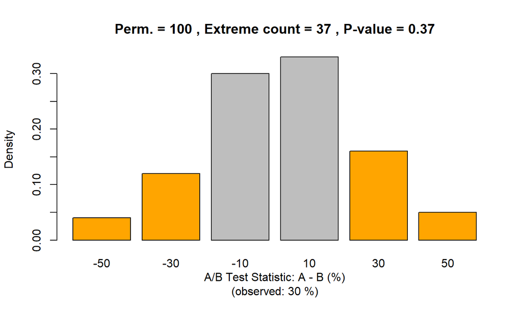

## Code – Permutation Test – Histogram (Counts)

```
## perm_res
## -50 -30 -10  10  30  50
##   4  12  30  33  16   5
```

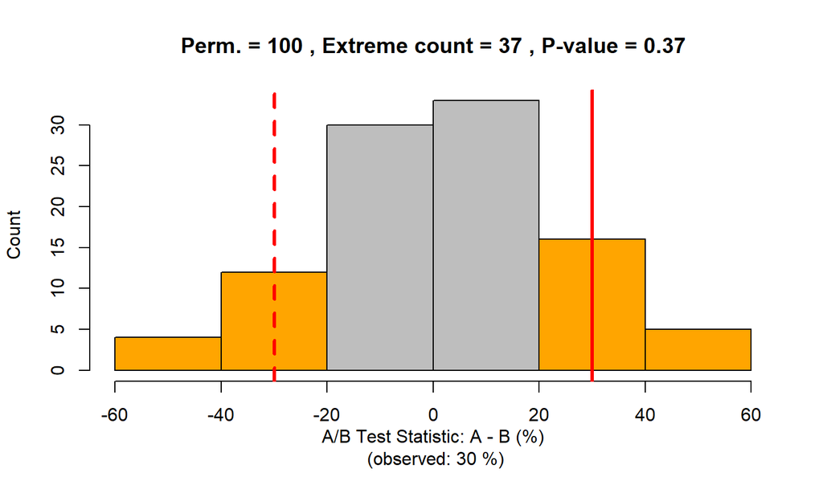

## Code – Permutation Test – Histogram (Prob.)

```
## perm_res
## -50 -30 -10  10  30  50
##   4  12  30  33  16   5
```

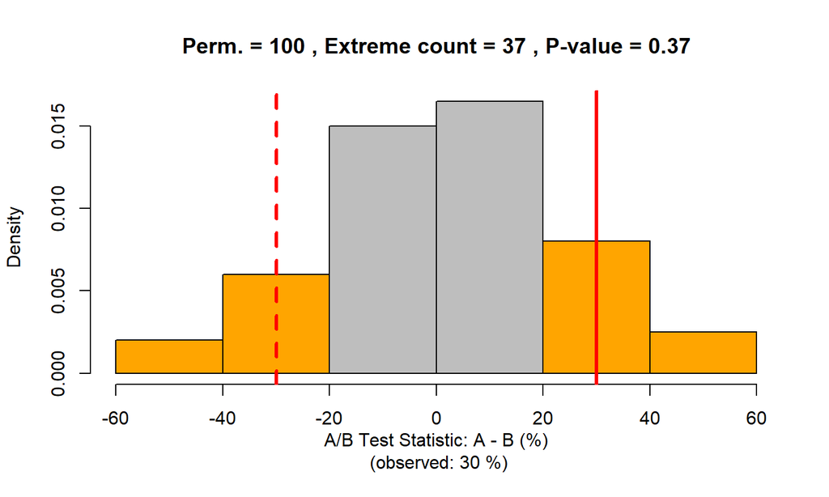

## Code – Permutation Test – Density Plot (Prob.)

```
## perm_res
## -50 -30 -10  10  30  50
##   4  12  30  33  16   5
```

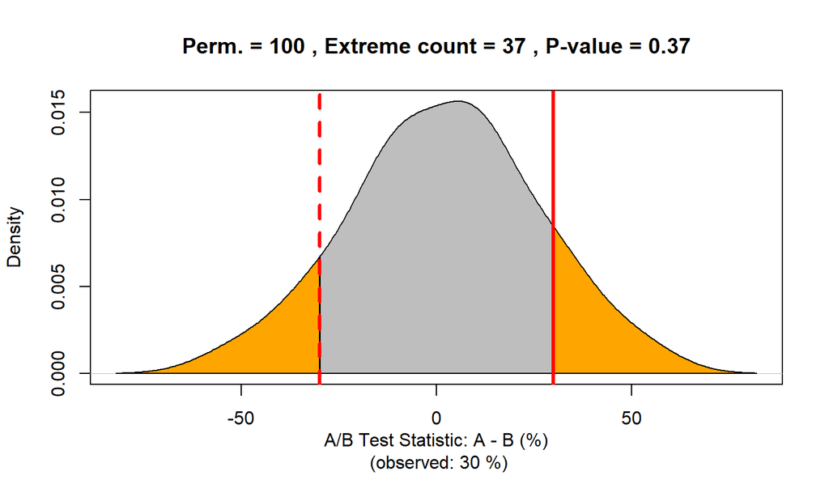

## Code – General Solution

The previous code has been consolidated into functions in the `functions.R` script.

- The function `ab_permutation_test` can be used to perform the whole process of a Permutation Test for a given A/B Test (examples in the next slides).

```r
source("functions.R")
```

## Code – General Solution – Didactic Example

```r
ab_permutation_test(a_all=10, b_all=10, a_yes=7, b_yes=4, n_p=100, verbose=TRUE, random_seed=1)
```

```
## Observed Yes Rate (%):  A: 70 , B: 40 , A-B: 30
```

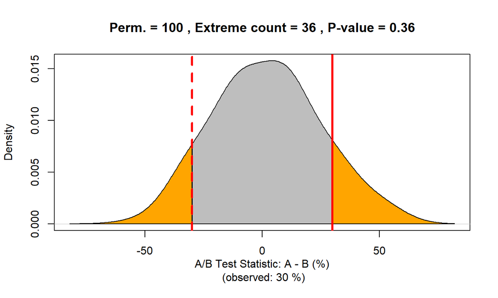

```
## [1] 0.36
```

## Code – General Solution – Other Example

```r
ab_permutation_test(a_all=1000, b_all=2000, a_yes=30, b_yes=100, n_p=1000, verbose=TRUE, random_seed=1)
```

```
## Observed Yes Rate (%):  A: 3 , B: 5 , A-B: -2
```

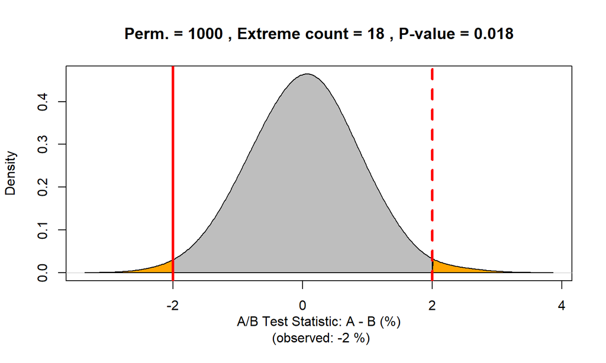

```
## [1] 0.018
```

## R Shiny App

## R Shiny App

You can explore A/B Testing with Permutation Test (i.e., the results of the `ab_permutation_test` function) by using the R Shiny App defined in the `app.R` file, available in the [presentation GitHub repository](https://github.com/nycdatasci/live-learning-sessions/tree/master/ab-testing-with-permutation-test).

Once you have the presentation files in your computer, you can launch the app as usual in RStudio (open the `app.R` file in RStudio and press the `Run App` button).

Alternatively, you can use the following code to run the app in your RStudio (this code downloads the app code from GitHub).

```r
library(shiny)

runGitHub(repo="live-learning-sessions", username="nycdatasci",
          subdir="ab-testing-with-permutation-test")
```